# Question 3: A ALSI Concentration analysis.

```
##  [1] 0.1219371676 0.0469522084 0.0325055622 0.0214829124 0.0174557952
##  [6] 0.0164854025 0.0162076011 0.0146655730 0.0145290150 0.0141958729
## [11] 0.0139804581 0.0138188454 0.0136312791 0.0134793789 0.0132392831
## [16] 0.0131354969 0.0130604079 0.0130031057 0.0128102874 0.0125633067
## [21] 0.0124692604 0.0123571656 0.0122753657 0.0121642195 0.0120658442
## [26] 0.0119506189 0.0117401716 0.0116319305 0.0115281598 0.0114763297
## [31] 0.0112688548 0.0112358433 0.0111324796 0.0111154945 0.0110004588
## [36] 0.0108230317 0.0107245817 0.0105960185 0.0104368426 0.0103614734
## [41] 0.0102579709 0.0100661761 0.0100131240 0.0099670663 0.0098048046
## [46] 0.0097461031 0.0096398922 0.0095131266 0.0093874768 0.0093099832
## [51] 0.0092563486 0.0091127150 0.0090258081 0.0089461868 0.0089063331
## [56] 0.0086196332 0.0083722197 0.0082961055 0.0081777540 0.0081366521
## [61] 0.0080075432 0.0077213188 0.0076485326 0.0073553613 0.0072220238
## [66] 0.0071936188 0.0069652937 0.0067005647 0.0065096453 0.0061858230
## [71] 0.0061120966 0.0058573756 0.0056363468 0.0051257942 0.0047365975
## [76] 0.0046037121 0.0045092139 0.0041087770 0.0040633377 0.0035553278
## [81] 0.0034979789 0.0032449389 0.0024645538 0.0023943016 0.0022219226
## [86] 0.0019030464 0.0017547524 0.0006516172
```

Here the proportions of the effects of the principal components are briefly reviewed although I will present them more conveniently below.

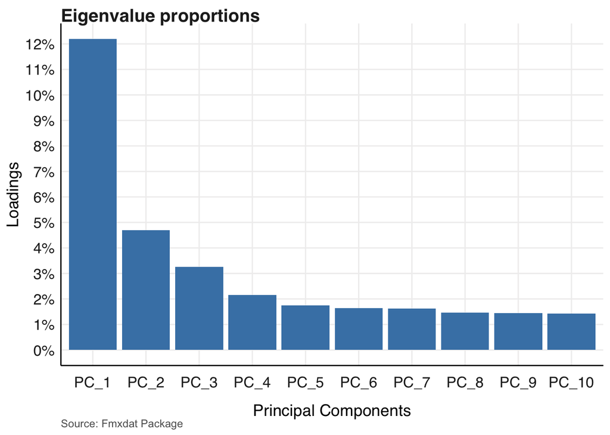

The direction I take from here is that as instead of loading supplementary variables onto the PCA analysis, I instead investigate correlations From a CAPM portfolio-theory perspective. For a slightly different perspective on the concentration of this index. Here the SA 3 Month bond is used as a proxy for the risk free rate. Below I convert it to a timeseries table and apply a CAPM, Three month rolling correlation.

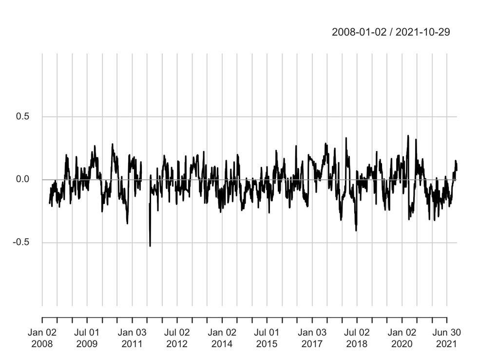

This rolling correlation is promising from a diversification perspective as it is clearly observable that it revolves around a zero mean consistently meaning that periods of high positive and high negative correlation persistence is unlikely. Taking into account that the highest factor influencing the first principal component was only 12% and drop down to below 5% for the second principal component it is substantiated that there are low levels of commonality of returns within the top 40 index. Before moving on to the following questions it is worth noting that having a portion of a portfolio in bonds during the pandemic would have provided good diversification against that of emerging markets and specifically South African equity as can be observed above.This does of course need to be analysed with in an optimisation routine of course.